# Practical Machine Learning Project

Shanthi Viswanathan

September 8, 2014

### Synopsis

Six young health participants were asked to perform one set of 10 repetitions of the Unilateral Dumbbell Biceps Curl in five different fashions:

- exactly according to the specification (Class A),
- throwing the elbows to the front (Class B),
- lifting the dumbbell only halfway (Class C),
- lowering the dumbbell only halfway (Class D) and
- throwing the hips to the front (Class E).

The goal of this project is to predict the manner in which the participants did the exercise. Machine Learning is the process of using algorithms to learn from data.

Read more:http://groupware.les.inf.puc-rio.br/har#dataset

### The Data

In the study referenced above, the data was obtained by attaching sensors (inertial measurement units) to both study participants, and weights, to measure the motion as exercises were performed.

In the final data set, available [here](https://d396qusza40orc.cloudfront.net/predmachlearn/pml-training.csv), each record consists of measurements obtained per person/exercise form in short span of time (0.5 - 2.5 seconds).

### Load needed libraries

```r
library(caret);library(lattice);library(ggplot2)
set.seed(34567)
```

### Data Processing

First, we import the data and take an initial look at it:

```r
pml_training <- read.csv("pml-training.csv", na.strings=c("NA","","#DIV/0!"), strip.white=TRUE)
dim(pml_training)
```

```
## [1] 19622   160
```

There are 19622 records with 160 variables.

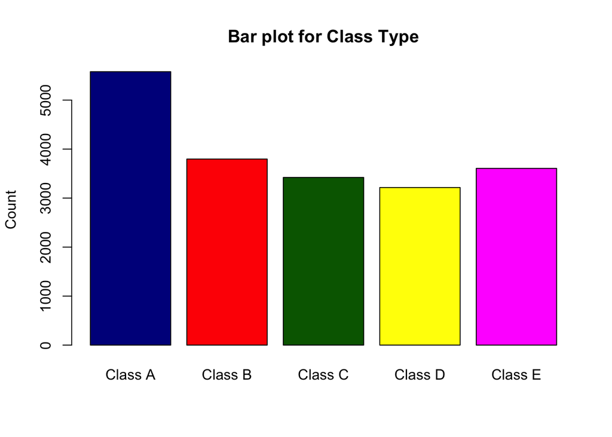

```r
barplot(table(pml_training$classe), main="Bar plot for Class Type",  names.arg=c("Class A", "Class B", "Class C", "Class D", "Class E"), col=c("darkblue","red","darkgreen","yellow","magenta"), ylab="Count")
```

The variable we will be predicting on is **classe**, and the data is split up between the five **classes** A, B, C, D and E. Let us inspect the data to see if we can identify columns that are not needed for our prediction model.

```r
na_data = sapply(pml_training, function(x) {sum(is.na(x))})
table(na_data)
```

```
## na_data
##     0 19216 19217 19218 19220 19221 19225 19226 19227 19248 19293 19294
##    60    67     1     1     1     4     1     4     2     2     1     1
## 19296 19299 19300 19301 19622
##     2     1     4     2     6
```

There are only 60 columns with no null values and the remaining 100 columns have almost all missing values. We can remove these columns from our training data and take a look at the remaining columns.

```r
bad_columns = names(na_data[na_data>19000])
new_training = pml_training[, !names(pml_training) %in% bad_columns]
```

The first seven columns are not related to the movement data and hence can be removed.

```r
new_training = new_training [,-c(1:7)]
```

Split the data into training and test.

```r
set.seed(0)
inTrain = createDataPartition(y=new_training$classe, p=0.7, list=FALSE)
training = new_training [inTrain,]
validate = new_training [-inTrain,]
dim(training)
```

```
## [1] 13737    53
```

#### Fit Random forest classification model

```r
ctrl <- trainControl(allowParallel=TRUE, method="cv", number=4)
modelRF <- train(classe ~ ., data=training, method="rf", trControl=ctrl)
modelRF
```

```
## Random Forest
##
## 13737 samples
##    52 predictor
##     5 classes: 'A', 'B', 'C', 'D', 'E'
##
## No pre-processing
## Resampling: Cross-Validated (4 fold)
##
## Summary of sample sizes: 10304, 10303, 10302, 10302
##
## Resampling results across tuning parameters:
##
##   mtry  Accuracy  Kappa  Accuracy SD  Kappa SD
##    2    1         1      0.002        0.003
##   27    1         1      0.002        0.002
##   52    1         1      0.002        0.003
##
## Accuracy was used to select the optimal model using  the largest value.
## The final value used for the model was mtry = 27.
```

The model’s accuracy is 1 and hence the out-of-sample error should be very minimal.

#### Estimating out-of-sample error

We use the above model and apply on the *validation* data set.

```r
predictorRF <- predict(modelRF, validate)
cm <- confusionMatrix(predictorRF, validate$classe)
cm
```

```
## Confusion Matrix and Statistics
##
##           Reference
## Prediction    A    B    C    D    E
##          A 1668    5    0    0    0
##          B    4 1128    1    0    1
##          C    1    5 1018    9    1
##          D    0    1    7  954    3
##          E    1    0    0    1 1077
##
## Overall Statistics
##
##                Accuracy : 0.993
##                  95% CI : (0.991, 0.995)
##     No Information Rate : 0.284
##     P-Value [Acc > NIR] : <2e-16
##
##                   Kappa : 0.991
##  Mcnemar's Test P-Value : NA
##
## Statistics by Class:
##
##                      Class: A Class: B Class: C Class: D Class: E
## Sensitivity             0.996    0.990    0.992    0.990    0.995
## Specificity             0.999    0.999    0.997    0.998    1.000
## Pos Pred Value          0.997    0.995    0.985    0.989    0.998
## Neg Pred Value          0.999    0.998    0.998    0.998    0.999
## Prevalence              0.284    0.194    0.174    0.164    0.184
## Detection Rate          0.283    0.192    0.173    0.162    0.183
## Detection Prevalence    0.284    0.193    0.176    0.164    0.183
## Balanced Accuracy       0.998    0.995    0.994    0.994    0.997
```

The accuracy on validation data set is 0.9932 which is very good. We can be **95% confident that the out-of-sample error of our model is between 0.9244% and 0.486%**.

#### Talk about Importance

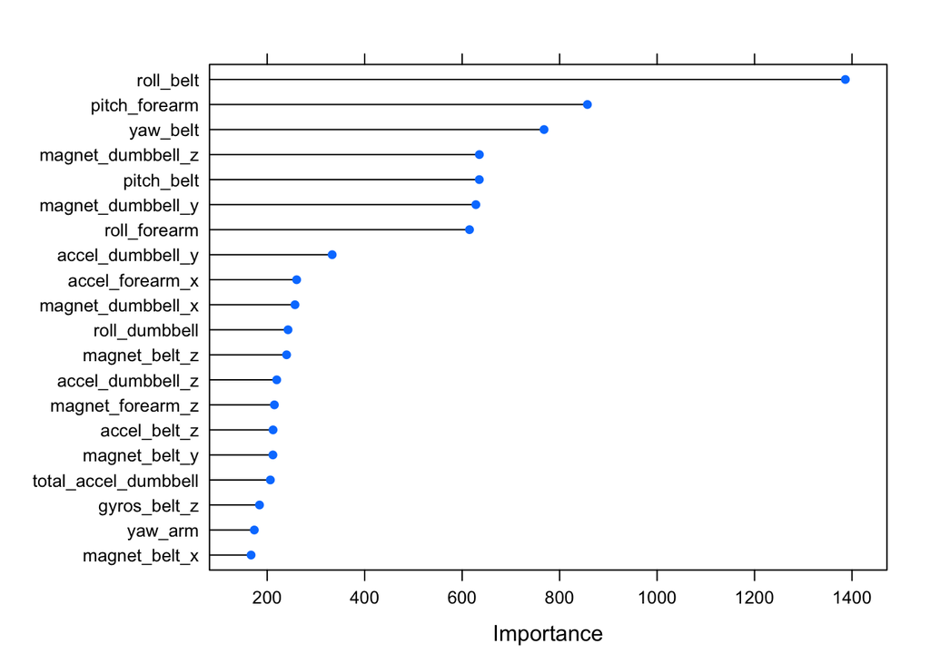

```r
plot(varImp (modelRF , scale = FALSE), top = 20)
```

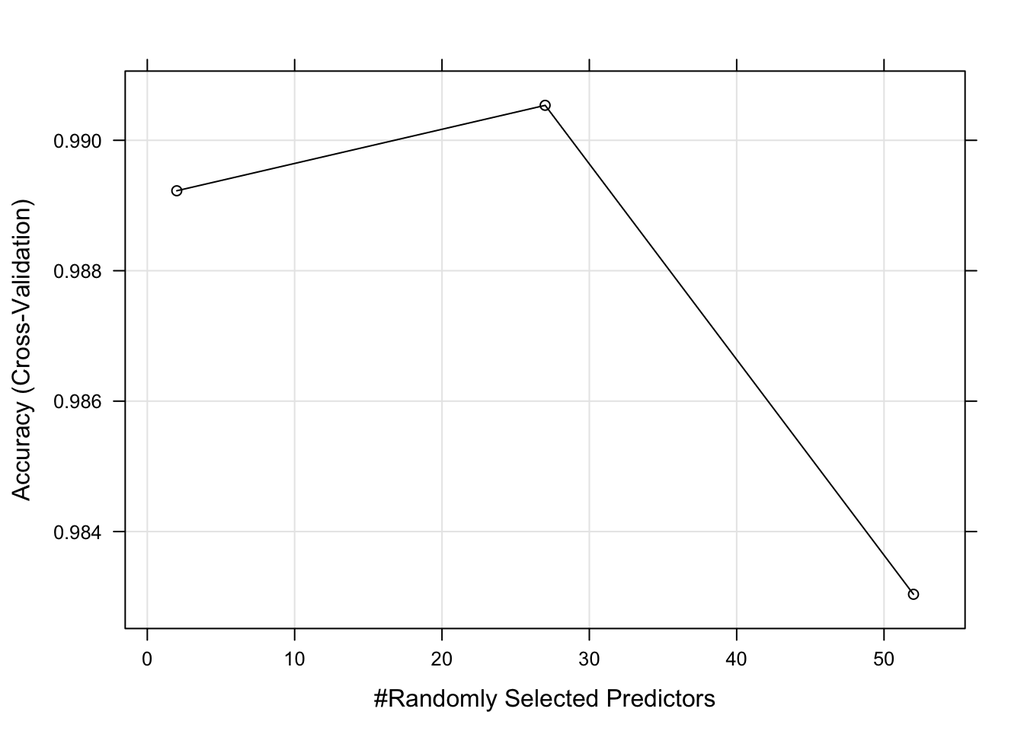

```r
trellis.par.set(caretTheme())
plot (modelRF , type = c("g", "o"))
```

### Predicting values for testing data set

```r
pml_test <- read.csv("pml-testing.csv", na.strings=c("NA","","#DIV/0!"),  strip.white=T)
pml_test <- pml_test[, !names(pml_test) %in% bad_columns]
pml_test <- pml_test [,-c(1:7)]
predict(modelRF, newdata=pml_test)
```

```
##  [1] B A B A A E D B A A B C B A E E A B B B
## Levels: A B C D E
```

### References

1. Velloso, E., et al. Qualitative Activity Recognition of Weight Lifting Exercises. Available at http://groupware.les.inf.puc-rio.br/work.jsf?p1=11201
2. Dataset source: http://groupware.les.inf.puc-rio.br/har